# *Faster Optimizers*

*Table Of Content:*

```
1. Optimizers
2. Fast Optimizers: Momentum Optimizer, Nesterov Accelerated Gradient, AdaGrad, RMSProp, Adam, Adamax & Nadam
3. Learning Rate Scheduling: Power Scheduling,  Exponential Scheduling, Piecewise Constant Scheduling,
4. Regularization: ℓ1 and ℓ2 regularization
5. Dropouts
6. Summary
```

# *Optimizers*

An optimizer is a method or algorithm to update the various parameters that can reduce the loss in much less effort.

An optimizer is a function or an algorithm that modifies the attributes of the neural network, such as weights and learning rate. Thus, it helps in reducing the overall loss and improve the accuracy. The problem of choosing the right weights for the model is a daunting task, as a deep learning model generally consists of millions of parameters. It raises the need to choose a suitable optimization algorithm for your application. Hence understanding these algorithms is necessary before having a deep dive into the field.

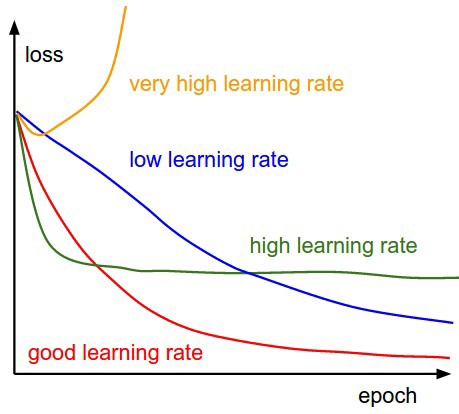

Good Learning Rate vs High Learning Rate vs Low Learning Rate vs Very High Learning Rate

# Model

```python
import sklearn
import tensorflow as tf
from tensorflow import keras
import numpy as np
import os
np.random.seed(42)
%matplotlib inline
import matplotlib as mpl
import matplotlib.pyplot as plt
```

```python
(X_train_full, y_train_full), (X_test, y_test) = keras.datasets.fashion_mnist.load_data()
X_train_full = X_train_full / 255.0
X_test = X_test / 255.0
X_valid, X_train = X_train_full[:5000], X_train_full[5000:]
y_valid, y_train = y_train_full[:5000], y_train_full[5000:]
```

```python
tf.random.set_seed(42)
np.random.seed(42)

model = keras.models.Sequential([
    keras.layers.Flatten( input_shape=[28,28]), #28*28=784
    keras.layers.Dense(128, activation="relu"), #variance=2/fan_in

    keras.layers.LeakyReLU(), #LeakyReLUα(z) = max(αz, z) #keras.layers.LeakyReLU(alpha=0.3, **kwargs)
    keras.layers.Dense(48, activation="relu"),
    keras.layers.Dense(10, activation='softmax')
])
```

```python
model.compile(loss="sparse_categorical_crossentropy",
              optimizer=keras.optimizers.Adam(learning_rate=1e-3
                                             ),
              metrics=["accuracy"])
```

```python
pixel_means = X_train.mean(axis=0, keepdims=True)
pixel_stds = X_train.std(axis=0, keepdims=True)
X_train_scaled = (X_train - pixel_means) / pixel_stds
X_valid_scaled = (X_valid - pixel_means) / pixel_stds
X_test_scaled = (X_test - pixel_means) / pixel_stds
```

```python
history = model.fit(X_train, y_train, epochs=10,
                    validation_data=(X_valid, y_valid))
```

```python
history.params
```

```
{'verbose': 1, 'epochs': 10, 'steps': 1719}
```

```python
print(history.epoch)
```

```
[0, 1, 2, 3, 4, 5, 6, 7, 8, 9]
```

```python
history.history.keys()
```

```
dict_keys(['loss', 'accuracy', 'val_loss', 'val_accuracy'])
```

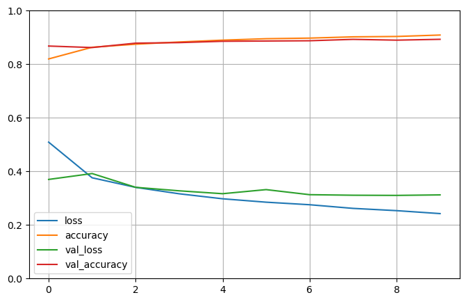

```python
import pandas as pd

pd.DataFrame(history.history).plot(figsize=(8, 5))
plt.grid(True)
plt.gca().set_ylim(0, 1)
plt.savefig("keras_learning_curves_plot")
plt.show()
```

# Faster Optimizers

### Momentum optimization

it will start out slowly, but it will quickly pick up momentum until it eventually reaches terminal velocity (if there is some friction or air resistance)

- $η$ is learning rate
- GD updates the weights θ by directly subtracting the gradient(derivative) of the cost function J(θ) w.r.t θ multiplied by the learning rate, α
- In contrast, regular Gradient Descent will simply take small, regular steps down the slope

```python
optimizer = keras.optimizers.SGD(learning_rate=0.001, momentum=0.9)
```

### Nesterov Accelerated Gradient

measures the gradient of the cost function not at the local position $θ$ but slightly ahead in the direction of the momentum, at $θ + βm$

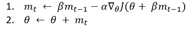

```python
optimizer = keras.optimizers.SGD(learning_rate=0.001, momentum=0.9, nesterov=True)
```

### AdaGrad

- Correct its direction earlier to point a bit more toward the global optimum.

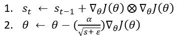

- adaptive learning rate -- this algorithm decays the learning rate, but it does so faster for steep dimensions than for dimensions with gentler slopes

```python
optimizer = keras.optimizers.Adagrad(learning_rate=0.001)
```

### RMSProp

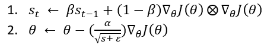

```python
optimizer = keras.optimizers.RMSprop(learning_rate=0.001, rho=0.9)
```

The decay rate, β is typically set to 0.9 and works well for most of the problems.

### *Adam Optimization*

- combines the ideas of momentum optimization and RMSProp
- just like momentum optimization, it keeps track of an exponentially decaying average of past gradients
- just like RMSProp, it keeps track of an exponentially decaying average of past squared gradients

Weights are updated using the equation:

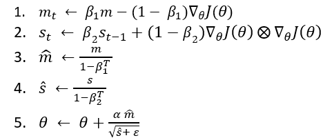

```python
optimizer = keras.optimizers.Adam(learning_rate=0.001, beta_1=0.9, beta_2=0.999)
```

There are 2 variants of Adam, namely *AdaMax* and *Nadam*.

### *Adamax Optimization*

Moreover, it drops out the step 4 and directly scale down the learning rate by factor of s. In some cases AdaMax is more stable than Adam, but it depends on the dataset.

```python
optimizer = keras.optimizers.Adamax(learning_rate=0.001, beta_1=0.9, beta_2=0.999)
```

### *Nadam Optimization*

It is Adam + Nesterov Accelerated Gradient, which helps it to converge slightly faster than Adam. Again, it depends on the dataset in hand.

```python
optimizer = keras.optimizers.Nadam(learning_rate=0.001, beta_1=0.9, beta_2=0.999)
```

The performance of various optimizers on the Fashion Mnist Data classification Model:

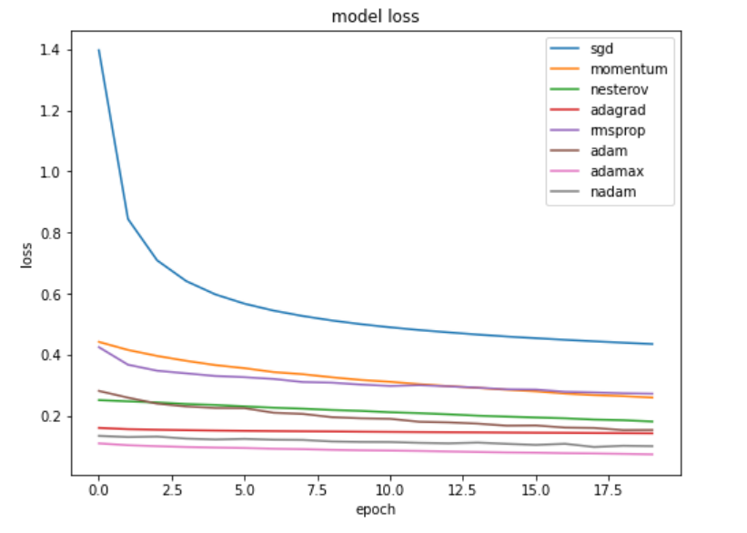

# *Learning Rate Scheduling*

- If you set it much too high, training may diverge
- If you set it too low, training will take a very long time

*solution: dynamic learning rate*

- start with a large learning rate and then reduce it once training stops making fast progress

### *Power Scheduling*

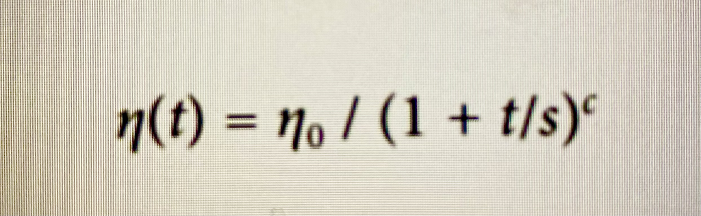

- Keras uses `c=1` and `s = 1 / decay`
- The learning rate drops at each step. After s steps, it is down to η0 / 2. After s more steps, it is down to η0 / 3, then it goes down to η0 / 4, then η0 / 5, and so on
- this schedule first drops quickly, then more and more slowly.

```python
optimizer = keras.optimizers.SGD(learning_rate=0.01, decay=1e-4)
```

```python
model = keras.models.Sequential([
    keras.layers.Flatten(input_shape=[28, 28]),
    keras.layers.Dense(300, activation="selu", kernel_initializer="lecun_normal"),
    keras.layers.Dense(100, activation="selu", kernel_initializer="lecun_normal"),
    keras.layers.Dense(10, activation="softmax")
])
model.compile(loss="sparse_categorical_crossentropy", optimizer=optimizer, metrics=["accuracy"])
```

```python
n_epochs = 25
history = model.fit(X_train_scaled, y_train, epochs=n_epochs,
                    validation_data=(X_valid_scaled, y_valid))
```

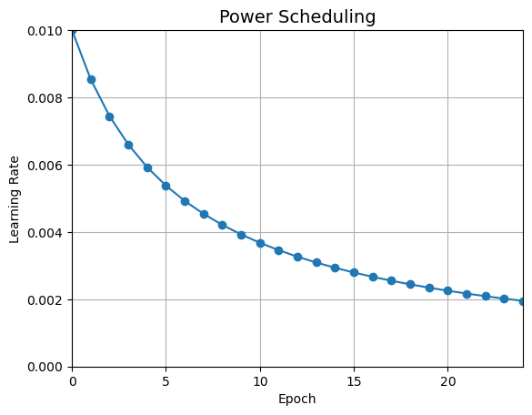

```python
import math

learning_rate = 0.01
decay = 1e-4
batch_size = 32
n_steps_per_epoch = math.ceil(len(X_train) / batch_size)
epochs = np.arange(n_epochs)
lrs = learning_rate / (1 + decay * epochs * n_steps_per_epoch)

plt.plot(epochs, lrs,  "o-")
plt.axis([0, n_epochs - 1, 0, 0.01])
plt.xlabel("Epoch")
plt.ylabel("Learning Rate")
plt.title("Power Scheduling", fontsize=14)
plt.grid(True)
plt.show()
```

### Exponential Scheduling

```python
def exponential_decay_fn(epoch):
    return 0.01 * 0.1**(epoch / 20)
```

```python
def exponential_decay(lr0, s):
    def exponential_decay_fn(epoch):
        return lr0 * 0.1**(epoch / s)
    return exponential_decay_fn

exponential_decay_fn = exponential_decay(lr0=0.01, s=20)
```

```python
model = keras.models.Sequential([
    keras.layers.Flatten(input_shape=[28, 28]),
    keras.layers.Dense(300, activation="selu", kernel_initializer="lecun_normal"),
    keras.layers.Dense(100, activation="selu", kernel_initializer="lecun_normal"),
    keras.layers.Dense(10, activation="softmax")
])
model.compile(loss="sparse_categorical_crossentropy", optimizer="nadam", metrics=["accuracy"])
n_epochs = 25
```

```python
lr_scheduler = keras.callbacks.LearningRateScheduler(exponential_decay_fn)
history = model.fit(X_train_scaled, y_train, epochs=n_epochs,
                    validation_data=(X_valid_scaled, y_valid),
                    callbacks=[lr_scheduler])
```

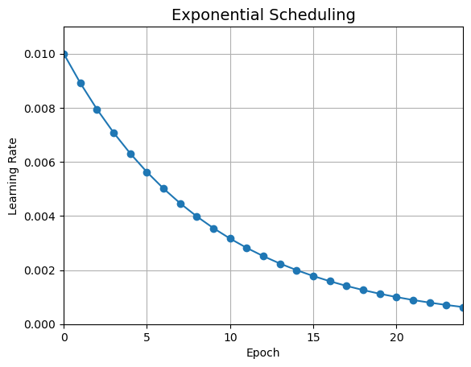

```python
plt.plot(history.epoch, history.history["lr"], "o-")
plt.axis([0, n_epochs - 1, 0, 0.011])
plt.xlabel("Epoch")
plt.ylabel("Learning Rate")
plt.title("Exponential Scheduling", fontsize=14)
plt.grid(True)
plt.show()
```

The schedule function can take the current learning rate as a second argument:

```python
def exponential_decay_fn(epoch, lr):
    return lr * 0.1**(1 / 20)
```

### Piecewise Constant Scheduling

```python
def piecewise_constant_fn(epoch):
    if epoch < 5:
        return 0.01
    elif epoch < 15:
        return 0.005
    else:
        return 0.001
```

```python
def piecewise_constant(boundaries, values):
    boundaries = np.array([0] + boundaries)
    values = np.array(values)
    def piecewise_constant_fn(epoch):
        return values[np.argmax(boundaries > epoch) - 1]
    return piecewise_constant_fn

piecewise_constant_fn = piecewise_constant([5, 15], [0.01, 0.005, 0.001])
```

```python
lr_scheduler = keras.callbacks.LearningRateScheduler(piecewise_constant_fn)

model = keras.models.Sequential([
    keras.layers.Flatten(input_shape=[28, 28]),
    keras.layers.Dense(300, activation="selu", kernel_initializer="lecun_normal"),
    keras.layers.Dense(100, activation="selu", kernel_initializer="lecun_normal"),
    keras.layers.Dense(10, activation="softmax")
])
model.compile(loss="sparse_categorical_crossentropy", optimizer="nadam", metrics=["accuracy"])
n_epochs = 25
history = model.fit(X_train_scaled, y_train, epochs=n_epochs,
                    validation_data=(X_valid_scaled, y_valid),
                    callbacks=[lr_scheduler])
```

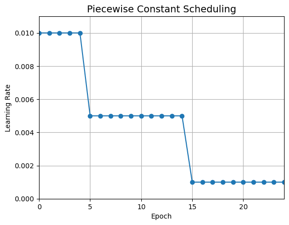

```python
plt.plot(history.epoch, [piecewise_constant_fn(epoch) for epoch in history.epoch], "o-")
plt.axis([0, n_epochs - 1, 0, 0.011])
plt.xlabel("Epoch")
plt.ylabel("Learning Rate")
plt.title("Piecewise Constant Scheduling", fontsize=14)
plt.grid(True)
plt.show()
```

# Regularization

### Avoiding Overfitting Through Regularization

## $\ell_1$ and $\ell_2$ regularization

- use ℓ2 regularization to constrain a neural network’s connection weights
- and/or ℓ1 regularization if you want a sparse model (with many weights equal to 0)
- The L1 regularization penalty is computed as: loss = l1 * reduce_sum(abs(x))
- The L2 regularization penalty is computed as loss = l2 * reduce_sum(square(x))

```python
layer = keras.layers.Dense(100, activation="elu",
                           kernel_initializer="he_normal",
                           kernel_regularizer=keras.regularizers.l2(0.01))
# or l1(0.1) for ℓ1 regularization with a factor of 0.1
# or l1_l2(0.1, 0.01) for both ℓ1 and ℓ2 regularization, with factors 0.1 and 0.01 respectively
```

```python
model = keras.models.Sequential([
    keras.layers.Flatten(input_shape=[28, 28]),
    keras.layers.Dense(300, activation="elu",
                       kernel_initializer="he_normal",
                       kernel_regularizer=keras.regularizers.l2(0.01)),
    keras.layers.Dense(100, activation="elu",
                       kernel_initializer="he_normal",
                       kernel_regularizer=keras.regularizers.l2(0.01)),
    keras.layers.Dense(10, activation="softmax",
                       kernel_regularizer=keras.regularizers.l2(0.01))
])
model.compile(loss="sparse_categorical_crossentropy", optimizer="nadam", metrics=["accuracy"])
n_epochs = 2
history = model.fit(X_train_scaled, y_train, epochs=n_epochs,
                    validation_data=(X_valid_scaled, y_valid))
```

```python
from functools import partial

RegularizedDense = partial(keras.layers.Dense,
                           activation="elu",
                           kernel_initializer="he_normal",
                           kernel_regularizer=keras.regularizers.l2(0.01))

model = keras.models.Sequential([
    keras.layers.Flatten(input_shape=[28, 28]),
    RegularizedDense(300),
    RegularizedDense(100),
    RegularizedDense(10, activation="softmax")
])
model.compile(loss="sparse_categorical_crossentropy", optimizer="nadam", metrics=["accuracy"])
n_epochs = 2
history = model.fit(X_train_scaled, y_train, epochs=n_epochs,
                    validation_data=(X_valid_scaled, y_valid))
```

## Dropout

- at every training step, every neuron (including the input neurons, but always excluding the output neurons) has a probability p of being temporarily “dropped out”
- The hyperparameter p is called the dropout rate, and it is typically set between 10% and 50%
- After training, neurons don’t get dropped anymore

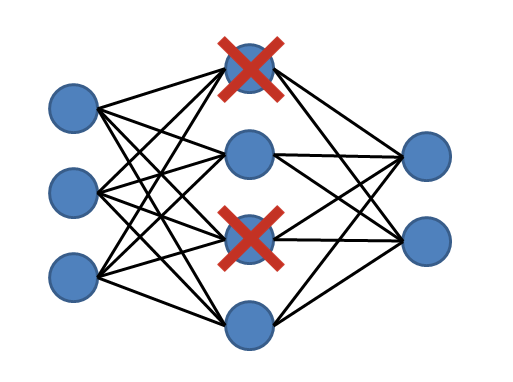

*Why does it work?*

- Neurons have to be as useful as possible on their own. They cannot rely excessively on just a few input neurons; they must pay attention to each of their input neurons. More robust network.
- The resulting neural network can be seen as an averaging ensemble of a total of $2^N$ possible networks (where N is the total number of droppable neurons)

```python
model = keras.models.Sequential([
    keras.layers.Flatten(input_shape=[28, 28]),
    keras.layers.Dropout(rate=0.2),
    keras.layers.Dense(300, activation="elu", kernel_initializer="he_normal"),
    keras.layers.Dropout(rate=0.2),
    keras.layers.Dense(100, activation="elu", kernel_initializer="he_normal"),
    keras.layers.Dropout(rate=0.2),
    keras.layers.Dense(10, activation="softmax")
])
model.compile(loss="sparse_categorical_crossentropy", optimizer="nadam", metrics=["accuracy"])
n_epochs = 2
history = model.fit(X_train_scaled, y_train, epochs=n_epochs,
                    validation_data=(X_valid_scaled, y_valid))
```

## Monte Carlo (MC) Dropout

- We just make 100 predictions over the test set
- setting training=True to ensure that the Dropout layer is active
- then stack the predictions. Since dropout is active, all the predictions will be different

```python
tf.random.set_seed(42)
np.random.seed(42)
```

```python
y_probas = np.stack([model(X_test_scaled, training=True)
                     for sample in range(100)])
y_proba = y_probas.mean(axis=0)
y_std = y_probas.std(axis=0)
```

```python
np.round(model.predict(X_test_scaled[:1]), 2)
```

```
array([[0.  , 0.  , 0.  , 0.  , 0.  , 0.03, 0.  , 0.12, 0.  , 0.84]],
      dtype=float32)
```

```python
np.round(y_probas[:, :1], 2)
```

```
array([[[0.  , 0.  , 0.  , 0.  , 0.  , 0.04, 0.  , 0.56, 0.  , 0.4 ]],

       [[0.  , 0.  , 0.  , 0.  , 0.  , 0.01, 0.  , 0.25, 0.  , 0.73]],

       [[0.  , 0.  , 0.  , 0.  , 0.  , 0.02, 0.  , 0.01, 0.  , 0.98]],

       [[0.  , 0.  , 0.  , 0.  , 0.  , 0.05, 0.  , 0.02, 0.  , 0.94]],

       [[0.  , 0.  , 0.  , 0.  , 0.  , 0.01, 0.  , 0.19, 0.  , 0.8 ]],

       [[0.  , 0.  , 0.  , 0.  , 0.  , 0.21, 0.  , 0.64, 0.03, 0.12]],

       [[0.  , 0.  , 0.  , 0.  , 0.  , 0.  , 0.  , 0.02, 0.  , 0.98]],

       [[0.  , 0.  , 0.  , 0.  , 0.  , 0.21, 0.  , 0.08, 0.  , 0.71]],

       [[0.  , 0.  , 0.  , 0.  , 0.  , 0.01, 0.  , 0.12, 0.  , 0.87]],

       [[0.  , 0.  , 0.  , 0.  , 0.  , 0.24, 0.  , 0.06, 0.  , 0.7 ]],

       [[0.  , 0.  , 0.  , 0.  , 0.  , 0.24, 0.  , 0.07, 0.  , 0.69]],

       [[0.  , 0.  , 0.  , 0.  , 0.  , 0.04, 0.  , 0.33, 0.  , 0.63]],

       [[0.  , 0.  , 0.  , 0.  , 0.  , 0.01, 0.  , 0.02, 0.  , 0.97]],

       [[0.  , 0.  , 0.  , 0.  , 0.  , 0.12, 0.  , 0.02, 0.  , 0.86]],

       [[0.  , 0.  , 0.  , 0.  , 0.  , 0.03, 0.  , 0.18, 0.  , 0.79]],

       [[0.  , 0.  , 0.  , 0.  , 0.  , 0.01, 0.  , 0.52, 0.  , 0.47]],

       [[0.  , 0.  , 0.  , 0.  , 0.  , 0.51, 0.  , 0.03, 0.  , 0.46]],

       [[0.  , 0.  , 0.  , 0.  , 0.  , 0.01, 0.  , 0.09, 0.  , 0.9 ]],

       [[0.  , 0.  , 0.  , 0.  , 0.  , 0.01, 0.  , 0.41, 0.  , 0.58]],

       [[0.  , 0.  , 0.  , 0.  , 0.  , 0.27, 0.  , 0.5 , 0.  , 0.22]],

```

[output cut: 145 more lines]

```

       [[0.  , 0.  , 0.  , 0.  , 0.  , 0.05, 0.  , 0.08, 0.  , 0.87]],

       [[0.  , 0.  , 0.  , 0.  , 0.  , 0.  , 0.  , 0.07, 0.  , 0.92]],

       [[0.  , 0.  , 0.  , 0.  , 0.  , 0.01, 0.  , 0.04, 0.  , 0.95]],

       [[0.  , 0.  , 0.  , 0.  , 0.  , 0.01, 0.  , 0.29, 0.  , 0.7 ]],

       [[0.  , 0.  , 0.  , 0.  , 0.  , 0.17, 0.  , 0.07, 0.  , 0.76]],

       [[0.  , 0.  , 0.  , 0.  , 0.  , 0.02, 0.  , 0.61, 0.  , 0.37]],

       [[0.  , 0.  , 0.  , 0.  , 0.  , 0.02, 0.  , 0.18, 0.  , 0.8 ]]],
      dtype=float32)
```

```python
y_std = y_probas.std(axis=0)
np.round(y_std[:1], 2)
```

```
array([[0.  , 0.  , 0.  , 0.  , 0.  , 0.16, 0.  , 0.18, 0.  , 0.23]],
      dtype=float32)
```

```python
y_pred = np.argmax(y_proba, axis=1)
```

```python
accuracy = np.sum(y_pred == y_test) / len(y_test)
accuracy
```

```
0.8571
```

*Alpha Dropout*

- A Dropout that keeps mean and variance of inputs to their original values, in order to ensure the self-normalizing property even after this dropout.
- Alpha Dropout fits well to Scaled Exponential Linear Units by randomly setting activations to the negative saturation value.

```python
class MCDropout(keras.layers.Dropout):
    def call(self, inputs):
        return super().call(inputs, training=True)

class MCAlphaDropout(keras.layers.AlphaDropout):
    def call(self, inputs):
        return super().call(inputs, training=True)
```

```python
tf.random.set_seed(42)
np.random.seed(42)
```

```python
mc_model = keras.models.Sequential([
    MCAlphaDropout(layer.rate) if isinstance(layer, keras.layers.AlphaDropout) else layer
    for layer in model.layers
])
```

```python
mc_model.summary()
```

```
Model: "sequential_27"
_________________________________________________________________
 Layer (type)                Output Shape              Param #
=================================================================
 flatten_24 (Flatten)        (None, 784)               0

 dropout_6 (Dropout)         (None, 784)               0

 dense_77 (Dense)            (None, 300)               235500

 dropout_7 (Dropout)         (None, 300)               0

 dense_78 (Dense)            (None, 100)               30100

 dropout_8 (Dropout)         (None, 100)               0

 dense_79 (Dense)            (None, 10)                1010

=================================================================
Total params: 266,610
Trainable params: 266,610
Non-trainable params: 0
_________________________________________________________________
```

```python
optimizer = keras.optimizers.SGD(learning_rate=0.01, momentum=0.9, nesterov=True)
mc_model.compile(loss="sparse_categorical_crossentropy", optimizer=optimizer, metrics=["accuracy"])
```

```python
mc_model.set_weights(model.get_weights())
```

```python
np.round(np.mean([mc_model.predict(X_test_scaled[:1]) for sample in range(100)], axis=0), 2)
```

```
array([[0.  , 0.  , 0.  , 0.  , 0.  , 0.03, 0.  , 0.12, 0.  , 0.84]],
      dtype=float32)
```

## Max norm

- For each neuron, it constrains the weights w of the incoming connections such that $∥ w ∥_2 ≤ r$, where r is the max-norm hyperparameter and $∥ · ∥_2$ is the ℓ2 norm

```python
layer = keras.layers.Dense(100, activation="selu", kernel_initializer="lecun_normal",
                           kernel_constraint=keras.constraints.max_norm(1.))
```

```python
MaxNormDense = partial(keras.layers.Dense,
                       activation="selu", kernel_initializer="lecun_normal",
                       kernel_constraint=keras.constraints.max_norm(1.))

model = keras.models.Sequential([
    keras.layers.Flatten(input_shape=[28, 28]),
    MaxNormDense(300),
    MaxNormDense(100),
    keras.layers.Dense(10, activation="softmax")
])
model.compile(loss="sparse_categorical_crossentropy", optimizer="nadam", metrics=["accuracy"])
n_epochs = 2
history = model.fit(X_train_scaled, y_train, epochs=n_epochs,
                    validation_data=(X_valid_scaled, y_valid))
```

## Summary

- Apply a good initialization strategy for the connection weights
- Use a good activation function
- Use Batch Normalization
- Reuse parts of a pretrained network
- Faster optimizers
- Regularization